# Factory Machine Status

## Comparing our model result to the dummy model result

### Model Accuracy

How good are our models compared to the dummy model?

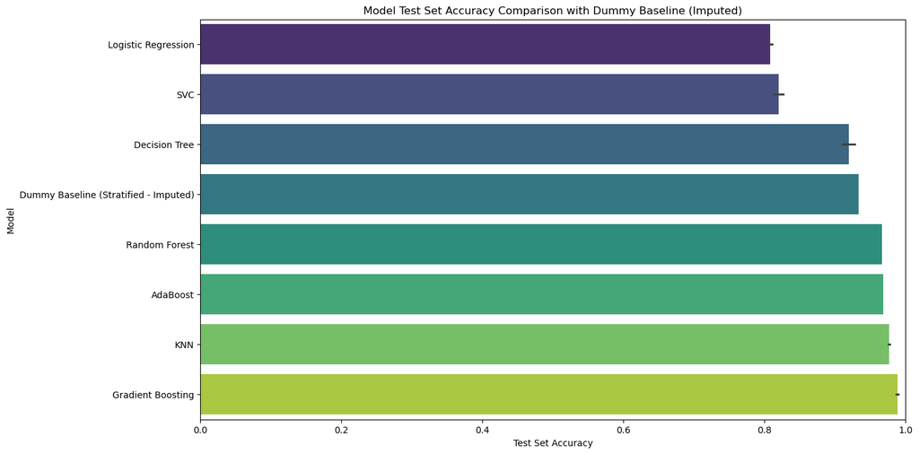

```python
evaluation_df_reset = evaluation_df.reset_index()
evaluation_df_reset = evaluation_df_reset[['Model', 'Test Set Accuracy']]


dummy_accuracy_row = pd.DataFrame([{'Model': 'Dummy Baseline (Stratified - Imputed)', 'Test Set Accuracy': dummy_test_accuracy_imputed}])
comparison_df_combined = pd.concat([evaluation_df_reset, dummy_accuracy_row], ignore_index=True)

comparison_df_combined = comparison_df_combined.sort_values(by='Test Set Accuracy', ascending=True)


plt.figure(figsize=(14, 8))
sns.barplot(x='Test Set Accuracy', y='Model', data=comparison_df_combined, palette='viridis')
plt.title('Model Test Set Accuracy Comparison with Dummy Baseline (Imputed)')
plt.xlabel('Test Set Accuracy')
plt.ylabel('Model')
plt.xlim(0, 1)
plt.show()
```

### Model Discriminative Power

It has good accuracy, but are the models more capable of discriminating results compared to the baseline?

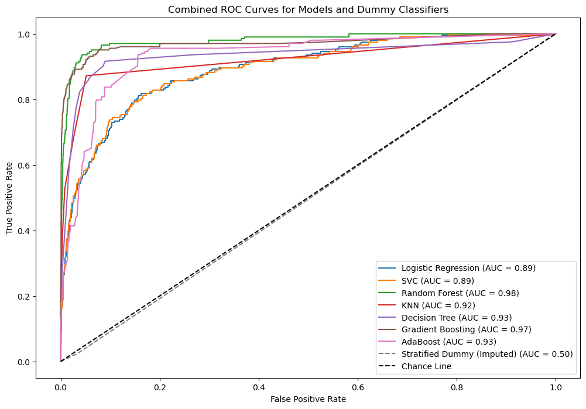

```python
plt.figure(figsize=(12, 8))


for model_name, result in results.items():
    best_pipeline = result['best_estimator']
    if hasattr(best_pipeline, 'predict_proba'):
        y_prob = best_pipeline.predict_proba(X_test)[:, 1]
        fpr, tpr, thresholds = roc_curve(y_test, y_prob)
        roc_auc = auc(fpr, tpr)
        plt.plot(fpr, tpr, label=f'{model_name} (AUC = {roc_auc:.2f})', linewidth=1.5)


fpr_imputed, tpr_imputed, _ = roc_curve(y_test_imputed, y_pred_proba_dummy_imputed)
roc_auc_imputed = auc(fpr_imputed, tpr_imputed)
plt.plot(fpr_imputed, tpr_imputed, linestyle='--', label=f'Stratified Dummy (Imputed) (AUC = {roc_auc_imputed:.2f})', linewidth=1.5)


plt.plot([0, 1], [0, 1], 'k--', label='Chance Line')


plt.xlabel('False Positive Rate')
plt.ylabel('True Positive Rate')
plt.title('Combined ROC Curves for Models and Dummy Classifiers')
plt.legend(loc='lower right')
plt.show()
```

# Final Phase: Determining the best model for predicting Factory Machine Status

Even tho we have found the model with the highest pure test accuracy is `Gradient Boosting`, we need to also compare the F1 Scores to determine the best model that suits this project.

The reason why, is because there is severe class imbalance in our datafile, hence the need to use F1 Score comparison instead of using our normal test accuracy data, as the result would be dominated by the majority class. For instance, we have 96.61% of our data as "0", hence if the model purely guesses everything as "0", it technically has a 96.61% accuracy, which is very misleading.

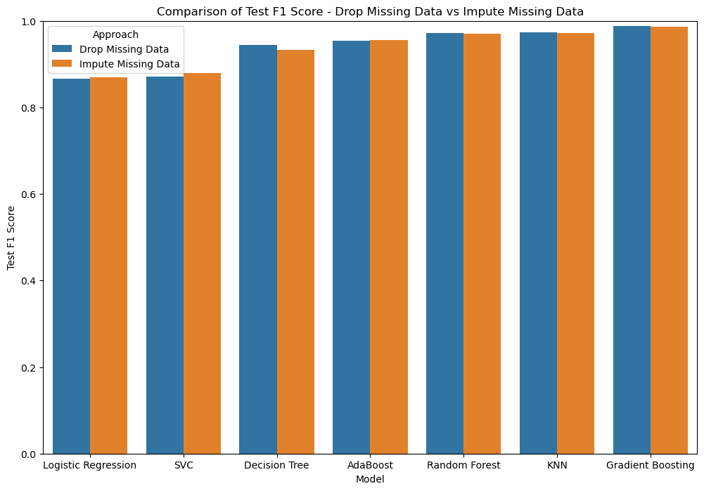

```python
evaluation_df = evaluation_df.sort_values(by='Test F1 Score', ascending=True)

plt.figure(figsize=(12, 8))
sns.barplot(x=evaluation_df.index, y='Test F1 Score', hue='Approach', data=evaluation_df)
plt.title('Comparison of Test F1 Score - Drop Missing Data vs Impute Missing Data')
plt.ylim(0, 1)
plt.show()
```

According to the bar graph, which was set to be sorted by ascending, `Gradient Boosting` remains the best classification model for this, when comparing the F1 Scores.

Even though it can be quite normal for gradient boosting to be able to learn imbalanced data well, there could still be biases towards predicting the majority class. We can further improve the model using other complex ways such as SMOTE (which oversamples the minority class), or using other gradient boosting models such as XGBoost or LightBGM, however these models are not under the Sklearn library, hence I will not be using them.

In conclusion, based on my results and reliability tests, `Gradient Boosting` is the most suitable model for this according to the hyperparameters I have tested it with.

# QNA

âœ”ï¸ How is your prediction task defined? And what is the meaning of the output variable?

âžœ The task is a classification task to predict Machine Status (this is the target) by learning the contributing factors (used as features)  
âžœ The output of 0 means the Machine is Normal and working as per usual, and 1 means the Machine is faulty and working abnormally.

âœ”ï¸Did you process the features in any way?

âžœ Yes, as there are missing values, I have processed them in two ways, both by imputing missing data using the most frequent datas, as well as dropping the rows with missing values, and then comparing to see which produced better results.  
I then also preprocessed them using StandardScaler() and OneHotEncoder before training the models with them to improve model performance and prevent feature dominance.

I have also refrained from feature engineering new features as we have a very imbalanced data. Featuring new features can cause the majority data to be even more dominant, and under-represent the minority data even more. Hence to be safe, I have chose not to feature engineer new features

âœ”ï¸ How did you select which learning algorithms to use?

âžœ Since this is a classification problem, I have selected models that are made for classification problems. Then determine which is the best model from the results and checks I have done.

âœ”ï¸ Did you try to tune the hyperparameters of the learning algorithm, and how?

âžœ Yes, I used hyperparameters to set the complexity of the learning algorithms. Since this dataset has severe issue of class imbalance (there are way more 0's than 1's), I have leaned more towards underfitting, to make sure the model is more accurate towards minor changes that could cause Machine Status (The target variable) to be '1'. Reason for this is because, for imbalanced datasets with suspiciously high accuracy, underfitting is safer because it reduces over-reliance on the majority class.

âœ”ï¸ How do you evaluate the quality of your machine learning models?

âžœ I first test their test accuracy to make sure it looks normal (for a dataset with ~96% '0's, the accuracy should not steer too far away from this accuracy). Then evaluate their F1 Score, since it's an imbalanced dataset, we'd need metrics other than test accuracy to determine its quality. I then conduct other tests, such as using an ROC curve to determine overfitting, and then using a checker which compares train accuracy with test accuracy to check for overfitting or underfitting. Then finally using a bar graph comparison to see which model performs best and is most suited for this project

âœ”ï¸ Is it possible to say something about which features the model considers important? (Whether this is possible depends on the type of classifier you are using)

âžœ Yes, under Phase 3, I have set up to show bargraphs showing the models which support it (models which have feature_importances_). They show what each model considers is important.